# Bayesian Linear Regression

Luis Martinez Lomeli

```r
library(ggplot2)
library(rstan)
rstan_options(auto_write = TRUE)
options(mc.cores = parallel::detectCores())
require(plyr)
library(reshape2)
library(utils)
```

Our first example is based on the `cars` dataset which is part of the `dataset` base library in R. It contains a data frame with 50 observations on 2 variables: speed (mph) vs distance (ft). These variables represen the speed and stopping distances of multiple cars. Let’s visualize its contents:

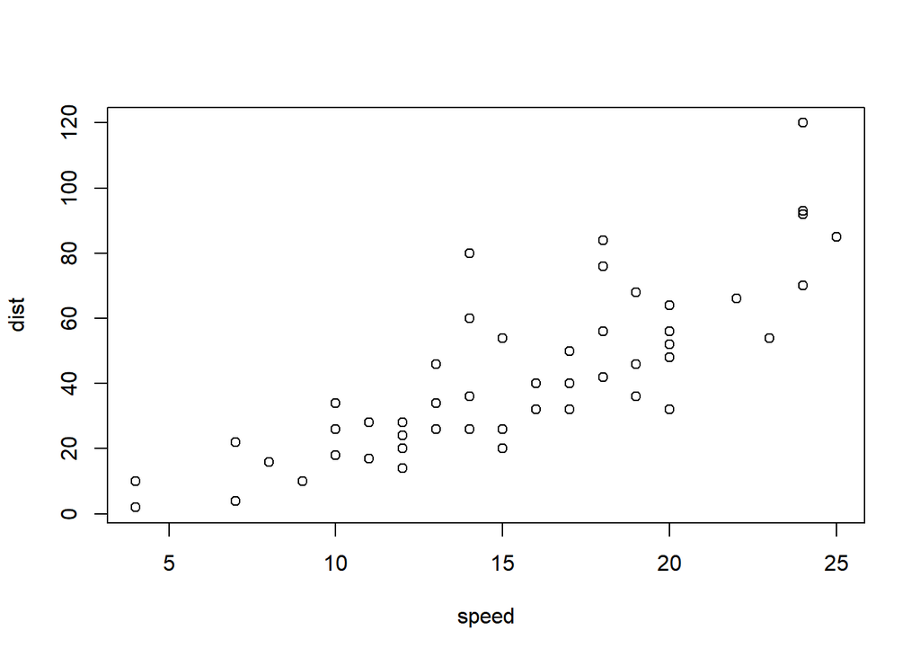

```r
plot(cars)
```

# Linear regression

Our first approach to model the relationship between car speed and stopping distance is using a linear model.

The model takes the form of

$y_i = \beta_0 + \beta_1\cdot x_i + \varepsilon_i$,

where $\beta_0$ and $\beta_1$ are the model parameters and represent the intercept and slope of the linear model. In this model, we assume constant error, ie, $\varepsilon_i ~ N(0, \sigma^2)$. Note that this assumption should be validated.

## Least squares fit

The first approach to fit this model is by following a least squares formulation. In this case, we define the residuals as

$r_i = y_i - \hat{y_i} = y_i - (\beta_0 + \beta_1 x_i)$.

Then, we formulate the Sum of Squared Residuals (SSR) as

$SSR = \sum_{i=1}^{n} r_i^2 = \sum_{i=1}^{n} r_i^2 (y_i - (\beta_0 + \beta_1 x_i))^2$.

```r
least_squares = function(param, data){

  y_hat = param[1] + param[2]*data$x

  resid_squared = (y_hat - data$y)^2

  return(sum(resid_squared))
}
```

Then, to fit the linear regression model to the data, we need to find the values of $\beta_0$ and $\beta_1$ for which SSR is minimal.

We can take the partial derivatives of SSR with respect of the parameters and find the roots of the equaions as a way to find the optimal parameters as shown [here](https://en.wikipedia.org/wiki/Least_squares#Solving_the_least_squares_problem). Alternatively, we can use an opimization rutine feeding the `least_squares` function that we defined above as

```r
data = list(x=cars$speed, y=cars$dist)


least_squares(param=c(1,2), data=data)
```

```
## [1] 22719
```

```r
fitted = optim(par=c(1,2), fn=least_squares, data=data,
               hessian=TRUE,method="BFGS")
```

and we obtain our point estimates and standard errors for the parameters using,

```r
#Estimates
fitted$par
```

```
## [1] -17.582360   3.932605
```

```r
#standard errors
sqrt(diag(solve(fitted$hessian)))
```

```
## [1] 0.31073259 0.01910402
```

## Linear regression with likelihood function

Maximum likelihood estimation and least squares estimation for linear regression models return similar point estimates. The difference relies in the assumption of Gaussian errors in the likelihood formulation. This means that our likelihood function is written as

$Y = N(\beta_0+\beta_1X, \sigma^2)$,

Note that this likelihood function now also contains the parameter $sigma$ which should be estimated along with $\beta_0$ and $\beta_1$ (since we do not know it in general). Also, note that we consider a log-transformation of the likelihood function to facilitate the numerical optimizer.

```r
lm_loglik = function(param, data){

  mean = param[1] + param[2]*data$x

  loglik = sum(x=dnorm(data$y, mean=mean, sd=param[3], log=TRUE))

  return(-loglik)

}
```

This log-likelihood function will return numerical values for given parameters, for example,

```r
lm_loglik(param=c(-10,2,1), data=data)
```

```
## [1] 20579.45
```

Now, we optimize the log-likelihood function using,

```r
fitted_lm_loglik = optim(par=c(1,1,1), fn=lm_loglik, data=data)
fitted_lm_loglik$par
```

```
## [1] -17.595074   3.931708  15.029669
```

and compare with the least squares estimates (no sigma):

```r
fitted$par
```

```
## [1] -17.582360   3.932605
```

We can compare these estimates with those provided by the `lm` function,

```r
fit_lm = lm(dist ~ speed, data=cars)
summary(fit_lm)
```

```
##
## Call:
## lm(formula = dist ~ speed, data = cars)
##
## Residuals:
##     Min      1Q  Median      3Q     Max
## -29.069  -9.525  -2.272   9.215  43.201
##
## Coefficients:
##             Estimate Std. Error t value Pr(>|t|)
## (Intercept) -17.5791     6.7584  -2.601   0.0123 *
## speed         3.9324     0.4155   9.464 1.49e-12 ***
## ---
## Signif. codes:  0 '***' 0.001 '**' 0.01 '*' 0.05 '.' 0.1 ' ' 1
##
## Residual standard error: 15.38 on 48 degrees of freedom
## Multiple R-squared:  0.6511, Adjusted R-squared:  0.6438
## F-statistic: 89.57 on 1 and 48 DF,  p-value: 1.49e-12
```

Finally, let’s visualize our fitted line

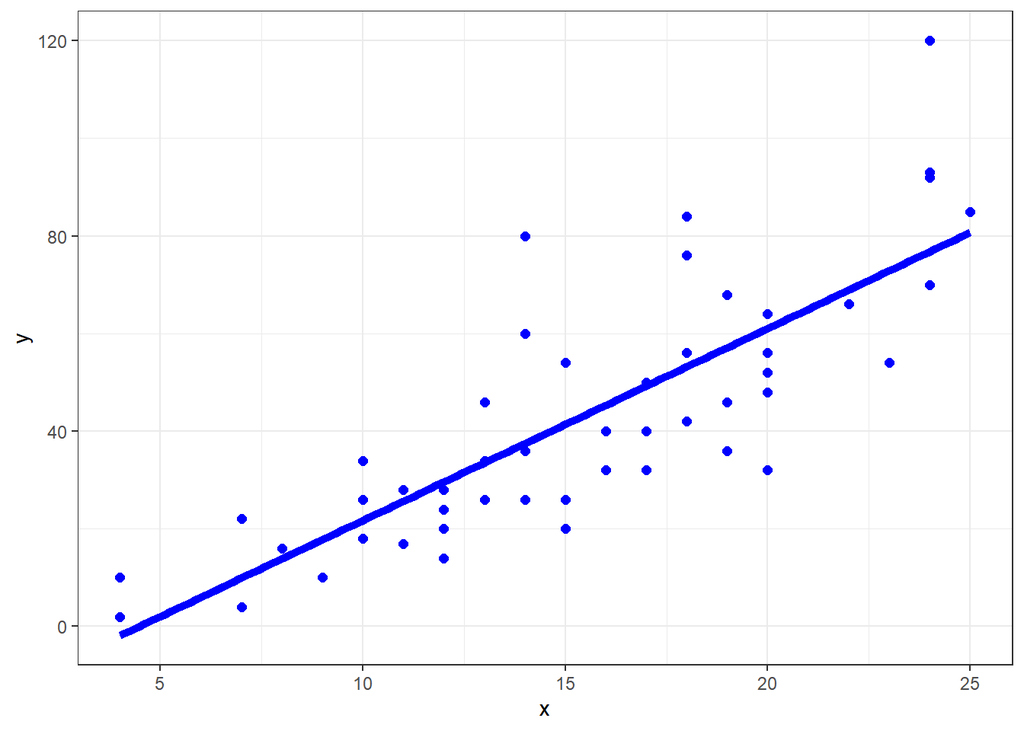

```r
x_pred = seq(min(data$x), max(data$x), length.out = 100)
y_pred = fitted$par[1] + fitted$par[2]*x_pred
df_pred = data.frame(x=x_pred, y=y_pred)

ggplot()+
  geom_point(data=as.data.frame(data), aes(x=x,y=y), colour="blue", size=2)  +
  geom_line(data = df_pred, aes(x=x_pred, y=y_pred), colour="blue", size=2) +
  theme_bw()
```

# Bayesian Linear regression

Given the likelihood

$Y = N(\beta_0+\beta_1X, \sigma^2)$,

our goal is to approximate the posterior distribution:

$p(\beta_0, \beta_1,\sigma|Y)\propto p(Y|\beta_0, \beta_1,\sigma)\times p(\beta_0, \beta_1,\sigma)$

where $p(\beta_0, \beta_1,\sigma)$ is the joint prior distribution for the parameters. It is common in the literature to assume that these parameters are independent from each other, this allows to obtain the simpler expression,

$p(\beta_0, \beta_1,\sigma)= p(\beta_0)p(\beta_1)p(\sigma)$

## STAN simple linear regression model

Now, we fit this model in STAN for the `cars` dataset. Note that we are not specifying any type of prior distributions.

```r
library(rstan)


stan_lm = "
data {
  int<lower=0> N; // number of records
  vector[N] x; // predictor vector
  vector[N] y; // response vector
}

parameters {
  real beta0; // intercept
  real beta1; // slope
  real<lower=0> sigma; // noise error
}

model {
  y ~ normal(beta0 + beta1  * x, sigma); // likelihood
}

"

stan_data = list(x=data$x, y=data$y, N=length(data$x))

stan_lm = stan(model_code=stan_lm, data=stan_data, iter=5000)
```

Now, let’s compare the difference between the `lm` estimates and STAN’s estimates

```r
print(stan_lm)
```

```
## Inference for Stan model: 36060d5538539a537295580946843c49.
## 4 chains, each with iter=5000; warmup=2500; thin=1;
## post-warmup draws per chain=2500, total post-warmup draws=10000.
##
##          mean se_mean   sd    2.5%     25%     50%     75%   97.5% n_eff Rhat
## beta0  -17.42    0.13 7.07  -31.61  -22.14  -17.46  -12.62   -3.58  3089    1
## beta1    3.92    0.01 0.43    3.07    3.63    3.92    4.21    4.78  2940    1
## sigma   15.84    0.03 1.71   12.93   14.65   15.69   16.90   19.60  4270    1
## lp__  -159.47    0.02 1.26 -162.79 -160.04 -159.16 -158.55 -158.03  3249    1
##
## Samples were drawn using NUTS(diag_e) at Thu Mar 25 19:29:40 2021.
## For each parameter, n_eff is a crude measure of effective sample size,
## and Rhat is the potential scale reduction factor on split chains (at
## convergence, Rhat=1).
```

```r
confint(fit_lm)
```

```
##                  2.5 %    97.5 %
## (Intercept) -31.167850 -3.990340
## speed         3.096964  4.767853
```

Since we approximated the posterior distribution for the parameters, we can visualize the pairs marginal plots and observe the relationship among the parameters

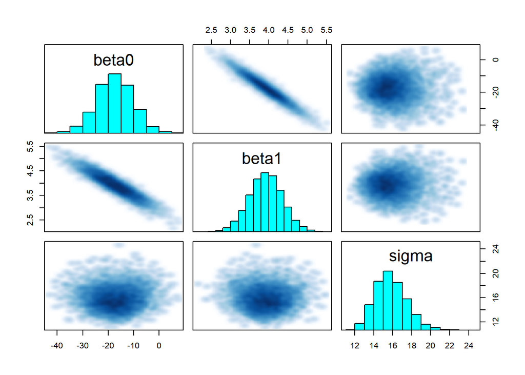

```r
pairs(stan_lm, pars=c('beta0', 'beta1', 'sigma'))
```

## Diagnostics

MCMC sampling is generally difficult to run for complex and non linear models. However, luckily, we have a few [convergence statistics](https://mc-stan.org/rstan/reference/Rhat.html) and plots that can tell us about the quality of our approximation for the posterior samples.

```r
print(stan_lm)
```

```
## Inference for Stan model: 36060d5538539a537295580946843c49.
## 4 chains, each with iter=5000; warmup=2500; thin=1;
## post-warmup draws per chain=2500, total post-warmup draws=10000.
##
##          mean se_mean   sd    2.5%     25%     50%     75%   97.5% n_eff Rhat
## beta0  -17.42    0.13 7.07  -31.61  -22.14  -17.46  -12.62   -3.58  3089    1
## beta1    3.92    0.01 0.43    3.07    3.63    3.92    4.21    4.78  2940    1
## sigma   15.84    0.03 1.71   12.93   14.65   15.69   16.90   19.60  4270    1
## lp__  -159.47    0.02 1.26 -162.79 -160.04 -159.16 -158.55 -158.03  3249    1
##
## Samples were drawn using NUTS(diag_e) at Thu Mar 25 19:29:40 2021.
## For each parameter, n_eff is a crude measure of effective sample size,
## and Rhat is the potential scale reduction factor on split chains (at
## convergence, Rhat=1).
```

For plots:

- [Traceplot](https://mc-stan.org/rstan/reference/stanfit-method-traceplot.html): Provides a visualization of the samples generated over all the iterations
- [Pairs plot](https://mc-stan.org/rstan/reference/stanfit-method-pairs.html): Bivariate visualization of MCMC parameters.

Others useful links:

- https://mc-stan.org/rstan/reference/stan_plot_diagnostics.html
- https://mc-stan.org/rstan/reference/check_hmc_diagnostics.html
- https://www.statlect.com/fundamentals-of-statistics/Markov-Chain-Monte-Carlo-diagnostics

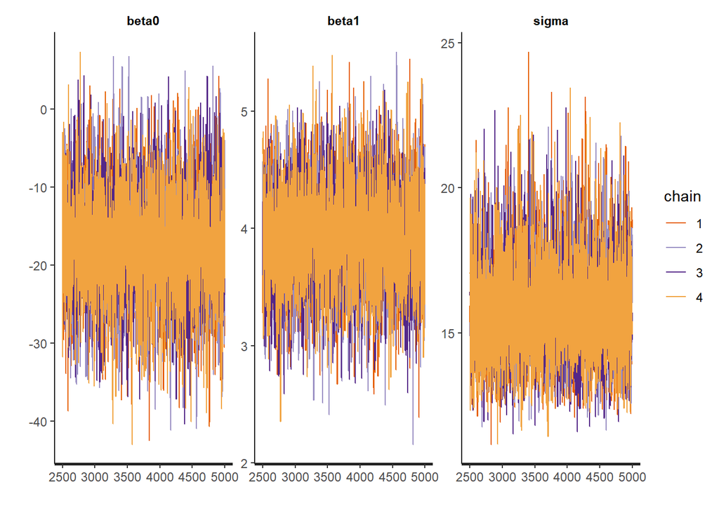

```r
traceplot(stan_lm)
```

## Stan Linear regression predict

We can use linear regression to predict for new unobserved values of the predictor denoted `x_pred`. In STAN we can implement this as:

```r
stan_lm_pred = "
data {
  int<lower=0> N1; // number of records
  vector[N1] x; // predictor vector
  vector[N1] y; // response vector

  int<lower=0> N2; // number of records for prediction
  vector[N2] x_pred; // For prediction
}

parameters {
  real beta0; // intercept
  real beta1; // slope
  real<lower=0> sigma; // noise error
}

model {
  y ~ normal(beta0 + beta1  * x, sigma); // likelihood
}


generated quantities{
  vector[N2] y_pred_mean;
  real y_pred[N2];

  y_pred_mean = beta0 + beta1 * x_pred;

  y_pred = normal_rng(y_pred_mean, sigma);

}


"

stan_data = list(x=data$x, y=data$y, N1=length(data$x),
                 x_pred=x_pred, N2=length(x_pred))

stan_lm_pred = stan(model_code=stan_lm_pred, data=stan_data, iter=10000)

print(stan_lm_pred, pars=c('beta0', 'beta1', 'sigma'))
```

```
## Inference for Stan model: 96ad9a1f3d891db5254948d87d87204a.
## 4 chains, each with iter=10000; warmup=5000; thin=1;
## post-warmup draws per chain=5000, total post-warmup draws=20000.
##
##         mean se_mean   sd   2.5%    25%    50%    75% 97.5% n_eff Rhat
## beta0 -17.66    0.09 6.92 -31.22 -22.33 -17.58 -12.97 -4.26  6343    1
## beta1   3.94    0.01 0.43   3.11   3.65   3.93   4.22  4.77  6470    1
## sigma  15.80    0.02 1.66  12.95  14.62  15.65  16.83 19.49  8608    1
##
## Samples were drawn using NUTS(diag_e) at Thu Mar 25 19:30:31 2021.
## For each parameter, n_eff is a crude measure of effective sample size,
## and Rhat is the potential scale reduction factor on split chains (at
## convergence, Rhat=1).
```

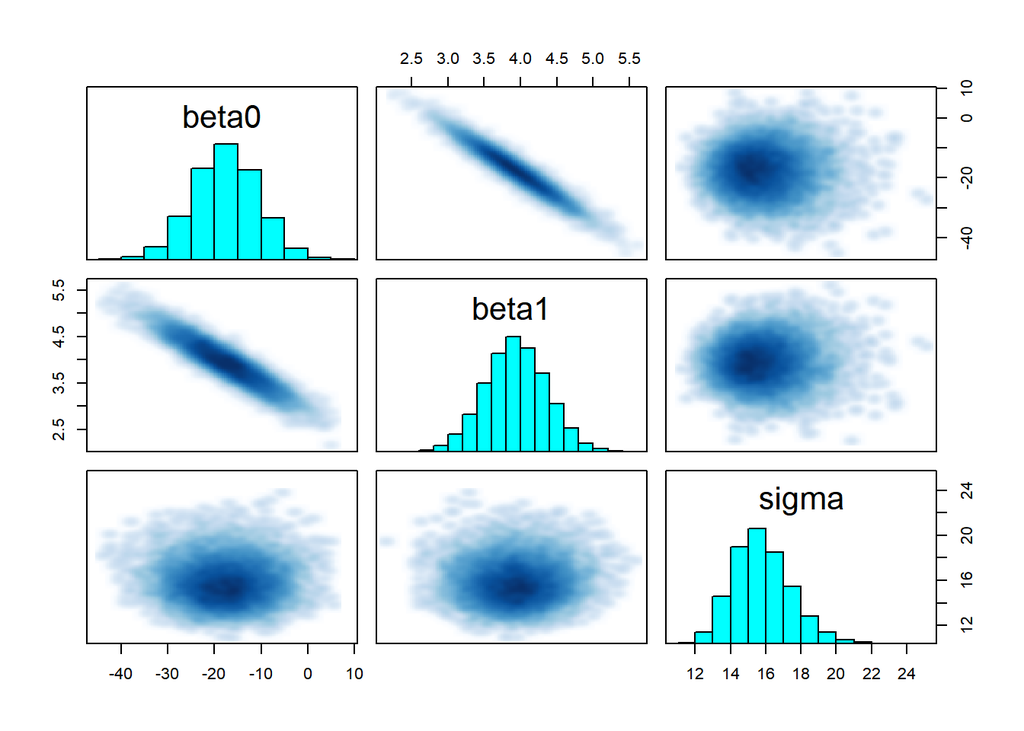

```r
pairs(stan_lm_pred, pars=c('beta0', 'beta1', 'sigma'))
```

## Exercise: Write this code in vectorized way:

```r
stan_lm_pred_vect = "
data {
  int<lower=0> N1; // number of records
  int<lower=0> K; // number of betas
  vector[N1, K] x; // predictors matrix
  vector[N1] y; // outcome vector

  int<lower=0> N2; // number of records for prediction
  vector[N2, K] x_pred // matrix of predictions

}

parameters {
  real alpha; // intercept
  vector[K] betas; // coefficients for predictors
  real<lower=0> sigma; // error scale
}

model {
  \\ No priors

  \\ Likelihood
  y ~ normal(x * betas , sigma); // likelihood
}


generated quantities{
  vector[N2] y_pred_mean;
  real y_pred[N2];

  y_pred_mean = betas * x_pred;

  y_pred = normal_rng(y_pred_mean, sigma);

}




"
```

# Visualize the fitted model

## Extract samples and prepare summary data frame

Now, let’s visualize our fitted model. First, we need to extract the samples from the STAN object, build the required dataframes with the right information to generate the plots.

```r
samples = extract(stan_lm_pred)

y_pred_summ = summary(stan_lm_pred, pars=c('y_pred'))$summary
# y_hat = as.numeric(y_hat_summ$summary[,"mean"])


df_pred = data.frame(x_pred=x_pred,
                     ymin = as.numeric(y_pred_summ[,'2.5%']),
                     ymax = as.numeric(y_pred_summ[,'97.5%']),
                     ymedian = as.numeric(y_pred_summ[,'50%']),
                     ymean = as.numeric(y_pred_summ[,'mean'])
                    )
#Add predictions from linear regression model
df_pred$y_pred_lm = predict(fit_lm, list(speed=df_pred$x_pred))

head(df_pred)
```

|  | x_pred | ymin | ymax | ymedian | ymean | y_pred_lm |
| --- | --- | --- | --- | --- | --- | --- |
| 1 | 4.000000 | -34.95884 | 31.47787 | -1.9094108 | -1.8498116 | -1.8494599 |
| 2 | 4.212121 | -34.57631 | 31.74001 | -1.0895454 | -1.2182793 | -1.0153125 |
| 3 | 4.424242 | -32.80141 | 32.57928 | -0.3856229 | -0.3224403 | -0.1811652 |
| 4 | 4.636364 | -32.98086 | 33.75965 | 0.3448164 | 0.4789920 | 0.6529821 |
| 5 | 4.848485 | -30.62444 | 34.59653 | 1.3562371 | 1.5138351 | 1.4871294 |
| 6 | 5.060606 | -31.32675 | 34.94408 | 2.3194735 | 2.2386309 | 2.3212767 |

Here, we visualize the original data and the predicted median of the credible intervals

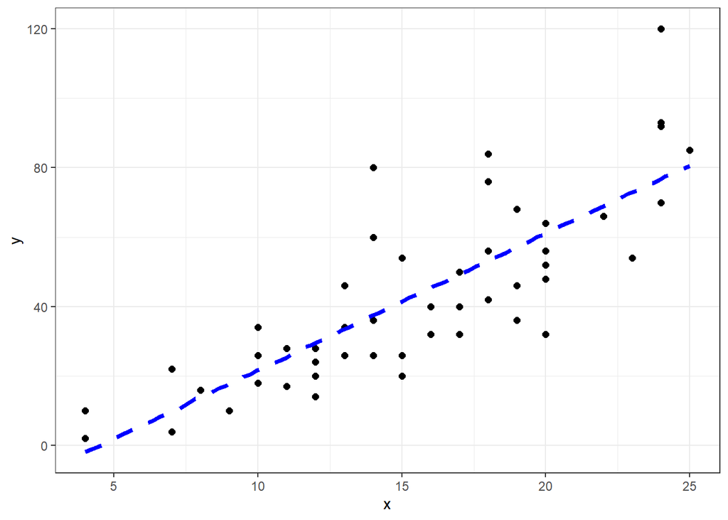

```r
# Median of Bayesian credible intervals

ggplot() +
  geom_point(data=as.data.frame(stan_data),
           aes(x=x,y=y), colour="black", size=2)  +
  geom_line(data=df_pred, aes(x=x_pred, y=ymedian), colour="blue", size=1.5,
            linetype='dashed') +
  theme_bw() -> lm_plot_base
print(lm_plot_base)
```

And we add the 95% Bayesian credible region

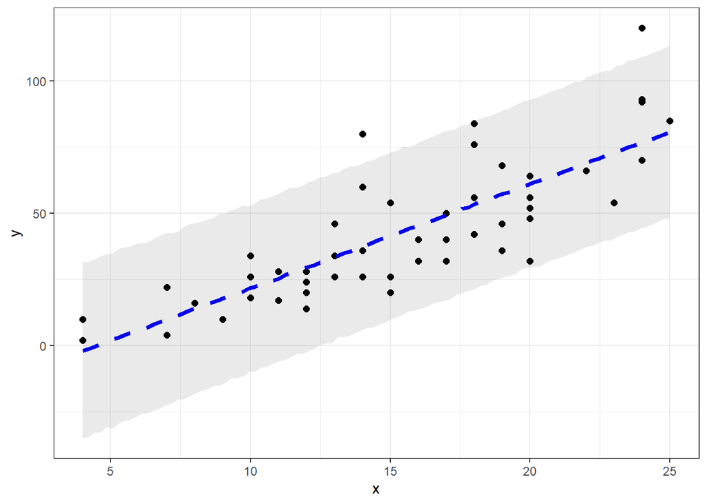

```r
# 95% Bayesian credible intervals
lm_plot = lm_plot_base +
  geom_ribbon(data=df_pred, aes(x=x_pred, ymin=ymin, ymax=ymax),
              alpha=0.1)
print(lm_plot)
```

*Spaghetti plots*: This type of plots allow to visualize multiple individual model solutions. This is possible since we have a distribution over the regression line from which we select 40 individuals lines samples.

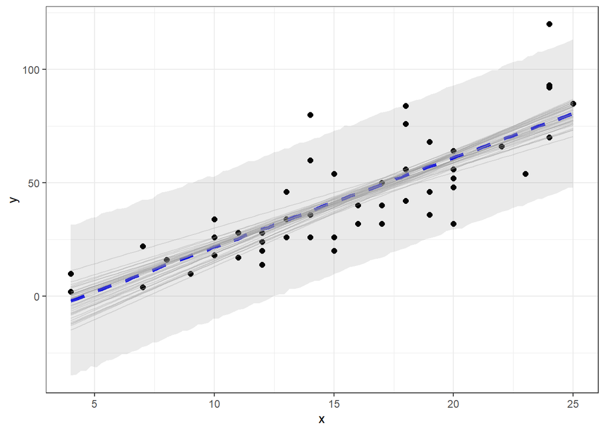

```r
TOT_SAMPLES = dim(samples$y_pred_mean)[1]

#Generate data frame with individual fitted lines aka spaguetti plots
TOT_SPAGUETTIS = 40
SAMPLES_ID_PLOT = sample(1:TOT_SAMPLES, TOT_SPAGUETTIS)
y_pred_mean <- adply(samples$y_pred_mean[SAMPLES_ID_PLOT,], 2)
tmp = melt(y_pred_mean)
names(tmp) = c("xid", "group", "y")
tmp <- mutate(tmp, x=x_pred[xid])

#Spaghetti plots: samples of individual fitted lines
lm_plot = lm_plot +
  geom_line(data=tmp, aes(x=x,y=y, group=group), colour="#999999", alpha=0.3)
print(lm_plot)
```

Finally, we compare the median of the Bayesian credible intervals with the point estimate provided by the `lm` model.

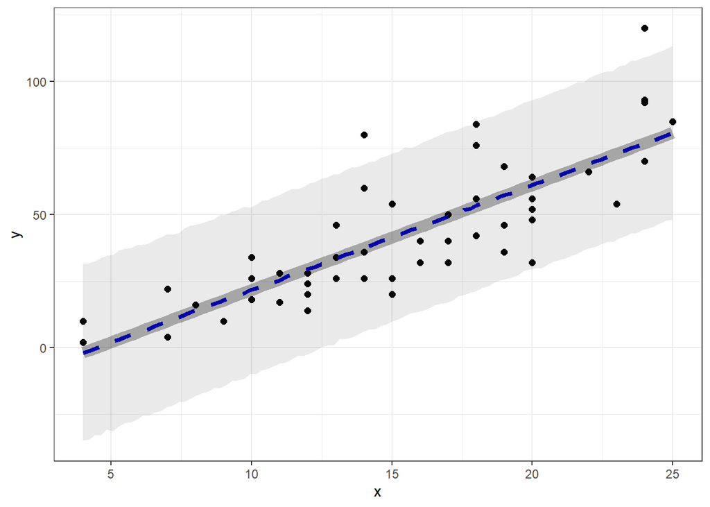

```r
# `lm` fitted line
lm_plot = lm_plot_base +
  geom_line(data = df_pred, aes(x=x_pred, y=y_pred_lm), colour="black", size=4,
            alpha=0.3) +
  geom_ribbon(data=df_pred, aes(x=x_pred, ymin=ymin, ymax=ymax),
              alpha=0.1)
print(lm_plot)
```